# Study of impact of Natural Disasters on Health and Economy

```r
opts_chunk$set(echo = TRUE, include=TRUE)
```

## Synopsis

NOAA data of natural calamities was studied. Impact was studied from economic point of view as well as public health angle. Data since 2001 was analysed. Under economic impact, property damage and crop damaged were considered. Under health impact, fatalities were given a higher weightage than injuries.

It was found that storms and floods cause most economic damage. Public health though imperilled at rough seas, is most damaged in excessive heat conditions.

## Data Processing

This clean, filtered and transformed data has been stored in the local directory under filename “Recent.data”. The code to obtain the clean data is appended at the end of this report.

### The Data Transformations -

The trailing script will download the requisit data - if already not done so.

I have used data downloaded on 24th July 2014 for this report.

The URL is [“[https://d396qusza40orc.cloudfront.net/repdata%2Fdata%2FStormData.csv.bz2”](https://d396qusza40orc.cloudfront.net/repdata%2Fdata%2FStormData.csv.bz2%22)]

Since the original data is large with 37 columns, we pickup only 8 columns of interest to us viz

- BGN_DATE - the date of the event
- EVTYPE - the type of event (there are 985 factors)
- FATALITIES - Number of deaths
- INJURIES - Number of non-fatal injured people
- PROPDMG - Amount of property damage
- PROPDMGEXP - unit of Property Damage
- CROPDMG - Amount of crop damage
- CROPDMGEXP - unit of crop damage amount

There are 902297 observations in the raw data To take only relevant information, we drop data prior to 2001. We also skip lines that are summaries.

Applying the units to the property and crop damage amounts, we get uniform dollar amounts.

```r
library(data.table)
    Recent<-read.table("./Recent.data", stringsAsFactors=FALSE)
   Recent<-cbind(Recent, yr=as.numeric(substr(Recent$BGN_DATE,1,4)))
    FiltDat<-nrow(Recent)
```

We will be using 488692 observations for analysis.

## Analysis

The Most likely events are -

```r
#Find the most likely events
    tb <- table(Recent$EVTYPE)
    MostLikelyEvents = names(tb[order(tb, decreasing = TRUE)])
    MostLikelyEvents[1:10]
```

```
##  [1] "HAIL"              "THUNDERSTORM WIND" "TSTM WIND"
##  [4] "FLASH FLOOD"       "FLOOD"             "TORNADO"
##  [7] "HIGH WIND"         "HEAVY SNOW"        "WINTER STORM"
## [10] "HEAVY RAIN"
```

### Economic Impact

On an average per incident, the most economically damaging events are -

```r
library(plyr)
#Find the average economical damage of events
     Eco<-ddply(Recent,.(EVTYPE),summarise,Damage=round(mean(PROPDMG+CROPDMG),2))
    Eco<-Eco[with(Eco, order(-Damage)), ]
    Eco[1:10,]
```

```
##                EVTYPE    Damage
## 75  HURRICANE/TYPHOON 817201282
## 130       STORM SURGE 359748125
## 74          HURRICANE  77477000
## 131  STORM SURGE/TIDE  31365122
## 140    TROPICAL STORM  12572779
## 43              FLOOD   7228314
## 143           TSUNAMI   7204100
## 23            DROUGHT   3902454
## 159          WILDFIRE   1849978
## 77          ICE STORM   1496917
```

```r
    EcoTop<-subset(Recent,Recent$EVTYPE %in% Eco[1:10,1])
    xEco<-xtabs(PROPDMG+CROPDMG ~ EVTYPE+yr , data=EcoTop)

    xEco
```

```
##                    yr
## EVTYPE                   2001      2002      2003      2004      2005
##   DROUGHT           1.274e+09 7.376e+08 1.218e+09 1.190e+06 1.388e+09
##   FLOOD             6.042e+08 4.674e+08 5.585e+08 1.174e+09 1.313e+09
##   HURRICANE         1.100e+06 8.373e+08 0.000e+00 0.000e+00 0.000e+00
##   HURRICANE/TYPHOON 0.000e+00 1.750e+08 1.017e+09 1.892e+10 5.180e+10
##   ICE STORM         1.003e+07 7.009e+08 2.782e+08 4.622e+07 1.461e+08
##   STORM SURGE       1.460e+06 1.056e+07 5.580e+07 4.323e+07 4.306e+10
##   STORM SURGE/TIDE  0.000e+00 0.000e+00 0.000e+00 0.000e+00 0.000e+00
##   TROPICAL STORM    5.188e+09 1.932e+08 8.490e+08 6.011e+08 2.866e+08
##   TSUNAMI           0.000e+00 0.000e+00 0.000e+00 0.000e+00 0.000e+00
##   WILDFIRE          0.000e+00 2.200e+04 2.363e+09 1.723e+07 4.088e+07
##                    yr
## EVTYPE                   2006      2007      2008      2009      2010
##   DROUGHT           2.498e+09 3.747e+08 6.450e+05 1.399e+07 5.807e+06
##   FLOOD             1.166e+11 1.031e+09 3.116e+09 6.375e+08 4.199e+09
##   HURRICANE         0.000e+00 3.770e+07 2.589e+09 3.000e+04 0.000e+00
##   HURRICANE/TYPHOON 0.000e+00 0.000e+00 0.000e+00 0.000e+00 0.000e+00
##   ICE STORM         2.200e+07 4.742e+08 8.747e+07 2.052e+08 5.338e+06
##   STORM SURGE       1.600e+05 0.000e+00 0.000e+00 0.000e+00 0.000e+00
##   STORM SURGE/TIDE  5.450e+05 4.000e+06 4.596e+09 1.180e+05 7.950e+05
##   TROPICAL STORM    4.495e+07 3.500e+05 2.620e+08 2.210e+05 1.772e+07
##   TSUNAMI           9.203e+06 0.000e+00 0.000e+00 8.102e+07 3.050e+05
##   WILDFIRE          4.118e+08 1.021e+09 2.019e+08 9.390e+07 2.469e+08
##                    yr
## EVTYPE                   2011
##   DROUGHT           3.139e+07
##   FLOOD             7.873e+09
##   HURRICANE         2.100e+07
##   HURRICANE/TYPHOON 0.000e+00
##   ICE STORM         7.918e+06
##   STORM SURGE       0.000e+00
##   STORM SURGE/TIDE  4.070e+07
##   TROPICAL STORM    1.632e+08
##   TSUNAMI           5.355e+07
##   WILDFIRE          6.581e+08
```

Combining the incidents per anum, the financial threats by event type are as per the table above and plot below.

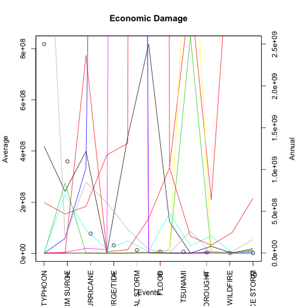

```r
#set parameters
par(mar=c(5,4,4,5)+.1)
plot(1:10, Eco[1:10,2], main = "Economic Damage", xlab = "Events", ylab="Average")
for(i in 1:10){ axis(1, at=c(i),col.ticks=i, labels= Eco[i,1], las=2)}
par(new=TRUE)
plot(as.numeric(dimnames(xEco)$yr), xEco[1,], type="l",col=1, xaxt="n",yaxt="n",xlab="", ylab="")
axis(4)
mtext("Annual",side=4,line=3)
for(i in 2:10)
{ lines(as.numeric(dimnames(xEco)$yr), xEco[i,], col=i) }
```

The hollow circles show average damage caused by an event.

**Typhoon -when it occurs causes most damage however, Floods in recent times seem to be taking the heaviest per anum economic toll.**

### Public Health Impact

Giving a 10 times weight to fatal injuries, on an average per incident, the most damaging to human life events are -

```r
library("plyr")
#Find the average Life damage of events
     Life<-ddply(Recent,.(EVTYPE),summarise,Damage=round(mean(10*FATALITIES+INJURIES),2))
    Life<-Life[with(Life, order(-Damage)), ]
Life[1:10,]
```

```
##                 EVTYPE Damage
## 114         ROUGH SEAS  30.00
## 143            TSUNAMI  22.95
## 75   HURRICANE/TYPHOON  21.76
## 17        COLD WEATHER  20.00
## 72          HIGH WATER  20.00
## 166 WINTER WEATHER MIX  11.33
## 33      EXCESSIVE HEAT  11.25
## 68           HIGH SEAS  10.33
## 24            DROWNING  10.00
## 76         ICE ON ROAD  10.00
```

Combining the incidents per anum, the life threats by event type are -

```r
#Further, looking at the aeging of the data,
    LifeTop<-subset(Recent,Recent$EVTYPE %in% Life[1:10,1])
    xLife<-xtabs(FATALITIES*10+INJURIES ~ EVTYPE+yr , data=LifeTop)

    xLife
```

```
##                     yr
## EVTYPE               2001 2002 2003 2004 2005 2006 2007 2008 2009 2010
##   COLD WEATHER          0   20    0    0    0    0    0    0    0    0
##   DROWNING              0   10    0    0    0    0    0    0    0    0
##   EXCESSIVE HEAT     2095 2048  534  134 1878 3043  756  281   82  453
##   HIGH SEAS            10   21    0    0    0    0    0    0    0    0
##   HIGH WATER           20    0    0    0    0    0    0    0    0    0
##   HURRICANE/TYPHOON     0  326   62 1069  458    0    0    0    0    0
##   ICE ON ROAD           0   10    0    0    0    0    0    0    0    0
##   ROUGH SEAS           20   40    0    0    0    0    0    0    0    0
##   TSUNAMI               0    0    0    0    0    0    0    0  449    0
##   WINTER WEATHER MIX   65    3    0    0    0    0    0    0    0    0
##                     yr
## EVTYPE               2011
##   COLD WEATHER          0
##   DROWNING              0
##   EXCESSIVE HEAT      498
##   HIGH SEAS             0
##   HIGH WATER            0
##   HURRICANE/TYPHOON     0
##   ICE ON ROAD           0
##   ROUGH SEAS            0
##   TSUNAMI              10
##   WINTER WEATHER MIX    0
```

Plotting the above information -

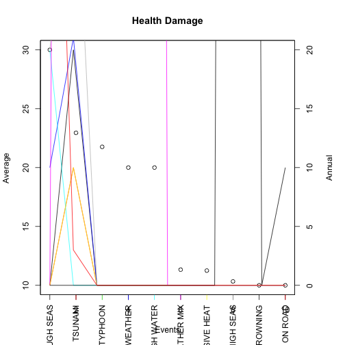

```r
#set parameters
par(mar=c(5,4,4,5)+.1)
plot(1:10, Life[1:10,2], main = "Health Damage", xlab = "Events", ylab="Average")
for(i in 1:10){ axis(1, at=c(i),col.ticks=i, labels= Life[i,1], las=2)}
par(new=TRUE)
plot(as.numeric(dimnames(xLife)$yr), xLife[1,], type="l",col=1, xaxt="n",yaxt="n",xlab="", ylab="")
axis(4)
mtext("Annual",side=4,line=3)
for(i in 2:10)
{ lines(as.numeric(dimnames(xLife)$yr), xLife[i,], col=i) }
```

The hollow circles show average damage caused by an event.

Although, on an average, rough seas take a heavier toll per instance, Heat is more prevalant and the cumulative effect of excessive heat appears to be the most damaging.

## Results

With respect to population health Excessive heat is the single largest contributor to damages across the United States.

Hurricanes, Storms and floods cost most economic consequences across the nation.

## Appendix - Preprocessing Source Code

```
colClass = c("NULL", "character", rep("NULL", 5), "character", rep("NULL", 14), "numeric", "numeric", "numeric", "character", "numeric", "character", rep("NULL", 9) )


Storm<-read.table("./Storm.bz2", header=T, sep=",", colClasses=colClass)


Storm$BGN_DATE <- as.Date(Storm$BGN_DATE, format="%M/%d/%Y %H:%M:%S" )
```

#Filter Data #Filter out older than 2001 - when the event types were standardized #Filter Summary lines

```
Recent<-(Storm[Storm$BGN_DATE > as.Date("2001/01/01") & ! (grepl("Summary", Storm$EVTYPE)),])
```

```
Recent[Recent$PROPDMGEXP == "M","PROPDMG"] = Recent[Recent$PROPDMGEXP == "M", "PROPDMG"] * 1000000


Recent[Recent$PROPDMGEXP == "B","PROPDMG"] = Recent[Recent$PROPDMGEXP == "B", "PROPDMG"] * 1000000000
```

```
Recent[Recent$CROPDMGEXP == "M","CROPDMG"] = Recent[Recent$CROPDMGEXP == "M", "CROPDMG"] * 1000000


Recent[Recent$CROPDMGEXP == "B","CROPDMG"] = Recent[Recent$CROPDMGEXP == "B", "CROPDMG"] * 1000000000
```

## End of Preprocessing Source code